# Algorithm Optimization & Selection for Spam Detection

Matheus Schmitz  
[LinkedIn](https://www.linkedin.com/in/matheusschmitz/)  
[Github Portfolio](https://matheus-schmitz.github.io/)

## Dataset

Source:  
http://archive.ics.uci.edu/ml/datasets/Spambase

Creators:  
Mark Hopkins, Erik Reeber, George Forman, Jaap Suermondt  
Hewlett-Packard Labs, 1501 Page Mill Rd., Palo Alto, CA 94304

Donor:  
George Forman (gforman at nospam hpl.hp.com) 650-857-7835

## Imports

```python
# Py Data Stack
import numpy as np
import pandas as pd
```

```python
# Visualization
import matplotlib
import matplotlib.pyplot as plt
%matplotlib inline
import seaborn as sns
```

```python
# Classifiers
import tpot
from tpot import TPOTClassifier
import sklearn
from sklearn.svm import SVC
from sklearn.ensemble import RandomForestClassifier
from sklearn.neighbors import KNeighborsClassifier
from sklearn.naive_bayes import GaussianNB
from sklearn.gaussian_process import GaussianProcessClassifier
from sklearn.discriminant_analysis import LinearDiscriminantAnalysis
```

```python
# Sklearn Auxilarty Functions
from sklearn.model_selection import train_test_split, KFold
from sklearn.preprocessing import StandardScaler
from sklearn.metrics import accuracy_score, confusion_matrix, roc_curve, auc
from sklearn.model_selection import GridSearchCV
from sklearn.pipeline import Pipeline
```

```python
# SMOTE
import imblearn
from imblearn.over_sampling import SMOTE
```

```python
# Package versions
%reload_ext watermark
%watermark -v -iv
```

```
Python implementation: CPython
Python version       : 3.7.9
IPython version      : 7.20.0

tpot      : 0.11.7
sklearn   : 0.24.1
seaborn   : 0.11.1
pandas    : 1.2.2
numpy     : 1.20.1
matplotlib: 3.3.4
imblearn  : 0.7.0
```

## 1. Loading the Dataset

```python
col_names = ['word_freq_make', 'word_freq_address', 'word_freq_all', 'word_freq_3d', 'word_freq_our', 'word_freq_over',
             'word_freq_remove', 'word_freq_internet', 'word_freq_order', 'word_freq_mail', 'word_freq_receive', 'word_freq_will',
             'word_freq_people', 'word_freq_report', 'word_freq_addresses', 'word_freq_free', 'word_freq_business', 'word_freq_email',
             'word_freq_you', 'word_freq_credit', 'word_freq_your', 'word_freq_font', 'word_freq_000', 'word_freq_money', 'word_freq_hp',
             'word_freq_hpl', 'word_freq_george', 'word_freq_650', 'word_freq_lab', 'word_freq_labs', 'word_freq_telnet', 'word_freq_857',
             'word_freq_data', 'word_freq_415', 'word_freq_85', 'word_freq_technology', 'word_freq_1999', 'word_freq_parts', 'word_freq_pm',
             'word_freq_direct', 'word_freq_cs', 'word_freq_meeting', 'word_freq_original', 'word_freq_project', 'word_freq_re', 'word_freq_edu',
             'word_freq_table', 'word_freq_conference', 'char_freq_;',  'char_freq_(', 'char_freq_[', 'char_freq_!', 'char_freq_$',
             'char_freq_#', 'capital_run_length_average', 'capital_run_length_longest', 'capital_run_length_total', 'LABEL']
len(col_names)
```

```
58
```

```python
# Load the dataset and define the column names
df = pd.read_csv('spambase.data', header=None, names=col_names)
print(f'df.shape: {df.shape}')
df.head()
```

```
df.shape: (4601, 58)
```

|  | word_freq_make | word_freq_address | word_freq_all | word_freq_3d | word_freq_our | word_freq_over | word_freq_remove | word_freq_internet | word_freq_order | word_freq_mail | ... | char_freq_; | char_freq_( | char_freq_[ | char_freq_! | char_freq_$ | char_freq_# | capital_run_length_average | capital_run_length_longest | capital_run_length_total | LABEL |
| --- | --- | --- | --- | --- | --- | --- | --- | --- | --- | --- | --- | --- | --- | --- | --- | --- | --- | --- | --- | --- | --- |
| 0 | 0.00 | 0.64 | 0.64 | 0.0 | 0.32 | 0.00 | 0.00 | 0.00 | 0.00 | 0.00 | ... | 0.00 | 0.000 | 0.0 | 0.778 | 0.000 | 0.000 | 3.756 | 61 | 278 | 1 |
| 1 | 0.21 | 0.28 | 0.50 | 0.0 | 0.14 | 0.28 | 0.21 | 0.07 | 0.00 | 0.94 | ... | 0.00 | 0.132 | 0.0 | 0.372 | 0.180 | 0.048 | 5.114 | 101 | 1028 | 1 |
| 2 | 0.06 | 0.00 | 0.71 | 0.0 | 1.23 | 0.19 | 0.19 | 0.12 | 0.64 | 0.25 | ... | 0.01 | 0.143 | 0.0 | 0.276 | 0.184 | 0.010 | 9.821 | 485 | 2259 | 1 |
| 3 | 0.00 | 0.00 | 0.00 | 0.0 | 0.63 | 0.00 | 0.31 | 0.63 | 0.31 | 0.63 | ... | 0.00 | 0.137 | 0.0 | 0.137 | 0.000 | 0.000 | 3.537 | 40 | 191 | 1 |
| 4 | 0.00 | 0.00 | 0.00 | 0.0 | 0.63 | 0.00 | 0.31 | 0.63 | 0.31 | 0.63 | ... | 0.00 | 0.135 | 0.0 | 0.135 | 0.000 | 0.000 | 3.537 | 40 | 191 | 1 |

5 rows × 58 columns

```python
# Check if there are any missing values and if all data types were properly loaded
df.info()
```

```
<class 'pandas.core.frame.DataFrame'>
RangeIndex: 4601 entries, 0 to 4600
Data columns (total 58 columns):
 #   Column                      Non-Null Count  Dtype
---  ------                      --------------  -----
 0   word_freq_make              4601 non-null   float64
 1   word_freq_address           4601 non-null   float64
 2   word_freq_all               4601 non-null   float64
 3   word_freq_3d                4601 non-null   float64
 4   word_freq_our               4601 non-null   float64
 5   word_freq_over              4601 non-null   float64
 6   word_freq_remove            4601 non-null   float64
 7   word_freq_internet          4601 non-null   float64
 8   word_freq_order             4601 non-null   float64
 9   word_freq_mail              4601 non-null   float64
```

[output cut: 50 more lines]

### 1.1. Train-Test Split

```python
# Split train and set data using class stratification
df_train, df_test= train_test_split(df, test_size=0.2, stratify=df.iloc[:,-1])
print(f'df_train.shape: {df_train.shape}')
print(f'df_test.shape: {df_test.shape}')
```

```
df_train.shape: (3680, 58)
df_test.shape: (921, 58)
```

### 1.2. Exploratory Analysis

Considering only the training data so as to leave testing data untouched

```python
# Check the distribution of the variables
df_train.describe()
```

|  | word_freq_make | word_freq_address | word_freq_all | word_freq_3d | word_freq_our | word_freq_over | word_freq_remove | word_freq_internet | word_freq_order | word_freq_mail | ... | char_freq_; | char_freq_( | char_freq_[ | char_freq_! | char_freq_$ | char_freq_# | capital_run_length_average | capital_run_length_longest | capital_run_length_total | LABEL |
| --- | --- | --- | --- | --- | --- | --- | --- | --- | --- | --- | --- | --- | --- | --- | --- | --- | --- | --- | --- | --- | --- |
| count | 3680.000000 | 3680.000000 | 3680.000000 | 3680.000000 | 3680.000000 | 3680.000000 | 3680.000000 | 3680.000000 | 3680.000000 | 3680.000000 | ... | 3680.000000 | 3680.000000 | 3680.000000 | 3680.000000 | 3680.000000 | 3680.000000 | 3680.000000 | 3680.000000 | 3680.000000 | 3680.000000 |
| mean | 0.104326 | 0.224799 | 0.279769 | 0.054228 | 0.310087 | 0.091864 | 0.113130 | 0.105326 | 0.089731 | 0.244329 | ... | 0.038564 | 0.135266 | 0.016735 | 0.272490 | 0.077965 | 0.043748 | 5.249336 | 49.709511 | 280.558967 | 0.394022 |
| std | 0.304140 | 1.338092 | 0.508302 | 1.221217 | 0.656361 | 0.253049 | 0.381496 | 0.407075 | 0.280806 | 0.662715 | ... | 0.248559 | 0.218538 | 0.114857 | 0.864163 | 0.250333 | 0.454713 | 33.133562 | 128.257333 | 555.548311 | 0.488706 |
| min | 0.000000 | 0.000000 | 0.000000 | 0.000000 | 0.000000 | 0.000000 | 0.000000 | 0.000000 | 0.000000 | 0.000000 | ... | 0.000000 | 0.000000 | 0.000000 | 0.000000 | 0.000000 | 0.000000 | 1.000000 | 1.000000 | 1.000000 | 0.000000 |
| 25% | 0.000000 | 0.000000 | 0.000000 | 0.000000 | 0.000000 | 0.000000 | 0.000000 | 0.000000 | 0.000000 | 0.000000 | ... | 0.000000 | 0.000000 | 0.000000 | 0.000000 | 0.000000 | 0.000000 | 1.593500 | 6.000000 | 35.000000 | 0.000000 |
| 50% | 0.000000 | 0.000000 | 0.000000 | 0.000000 | 0.000000 | 0.000000 | 0.000000 | 0.000000 | 0.000000 | 0.000000 | ... | 0.000000 | 0.065000 | 0.000000 | 0.000000 | 0.000000 | 0.000000 | 2.275000 | 15.000000 | 95.000000 | 0.000000 |
| 75% | 0.000000 | 0.000000 | 0.420000 | 0.000000 | 0.390000 | 0.000000 | 0.000000 | 0.000000 | 0.000000 | 0.170000 | ... | 0.000000 | 0.186000 | 0.000000 | 0.325000 | 0.054250 | 0.000000 | 3.734000 | 44.000000 | 266.250000 | 1.000000 |
| max | 4.540000 | 14.280000 | 5.100000 | 42.810000 | 8.330000 | 3.570000 | 7.270000 | 11.110000 | 5.260000 | 18.180000 | ... | 4.385000 | 4.271000 | 4.081000 | 32.478000 | 6.003000 | 19.829000 | 1102.500000 | 2204.000000 | 9163.000000 | 1.000000 |

8 rows × 58 columns

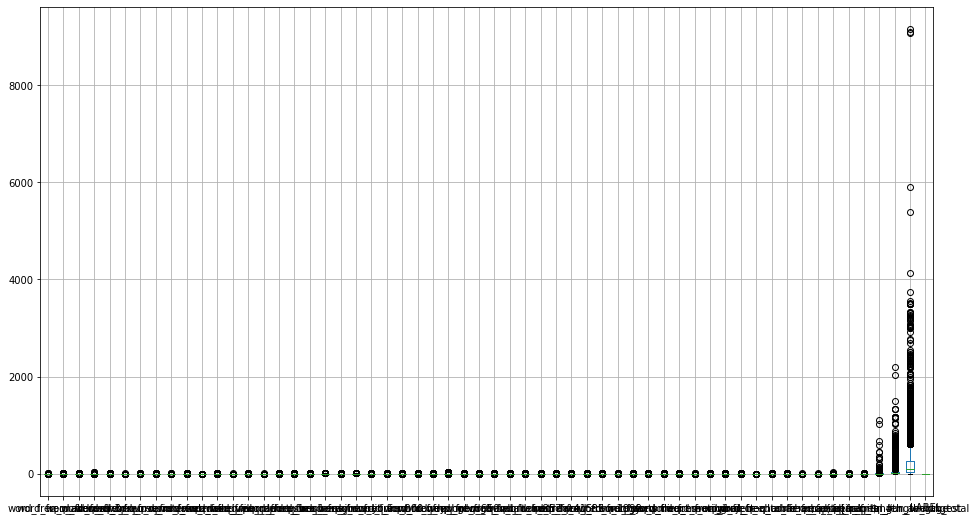

```python
# Check the distribution of variables using a boxplot
fix, ax = plt.subplots(figsize=(16,9))
df_train.boxplot()
plt.show()
```

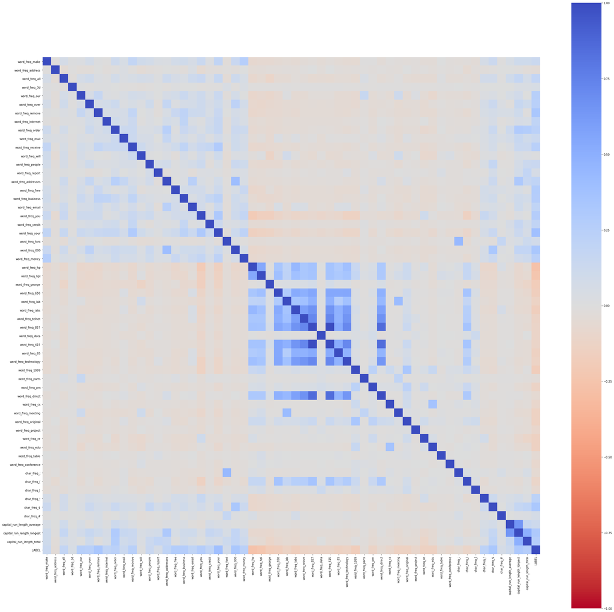

```python
# Correlation Matrix
fig, ax = plt.subplots(figsize=(40,40))
g = sns.heatmap(df_train.corr(), vmin=-1, vmax=1, cmap='coolwarm_r', square=True)
plt.show()
```

I don't see much strong evidence of correlation among variables, which would be a strong motivation to use PCA, SVD or other dimensionality reduction method, so I'll opt to skip those, while perhaps using a classifier that has some dimensionality reduction built-in, such as Linear Discriminant Analysis.

```python
# Coefficient of Variation (the variables with the largest std to mean ratio)
var_mean = df_train.mean(axis=0)
var_std = df_train.std(axis=0)
CV = var_std/var_mean
CV.head()
```

```
word_freq_make        2.915281
word_freq_address     5.952394
word_freq_all         1.816863
word_freq_3d         22.519930
word_freq_our         2.116698
dtype: float64
```

```python
# Identify the features with the highest CV
num_picks = int(np.floor(np.sqrt(df.shape[1])))
print(f'Number of features chosen: {num_picks}')
chosen_features = CV.sort_values(ascending=False).head(num_picks).index
chosen_features = [i for i in chosen_features]
print(f'List of features chosen: {chosen_features}')
```

```
Number of features chosen: 7
List of features chosen: ['word_freq_3d', 'word_freq_parts', 'word_freq_table', 'char_freq_#', 'word_freq_conference', 'word_freq_cs', 'word_freq_font']
```

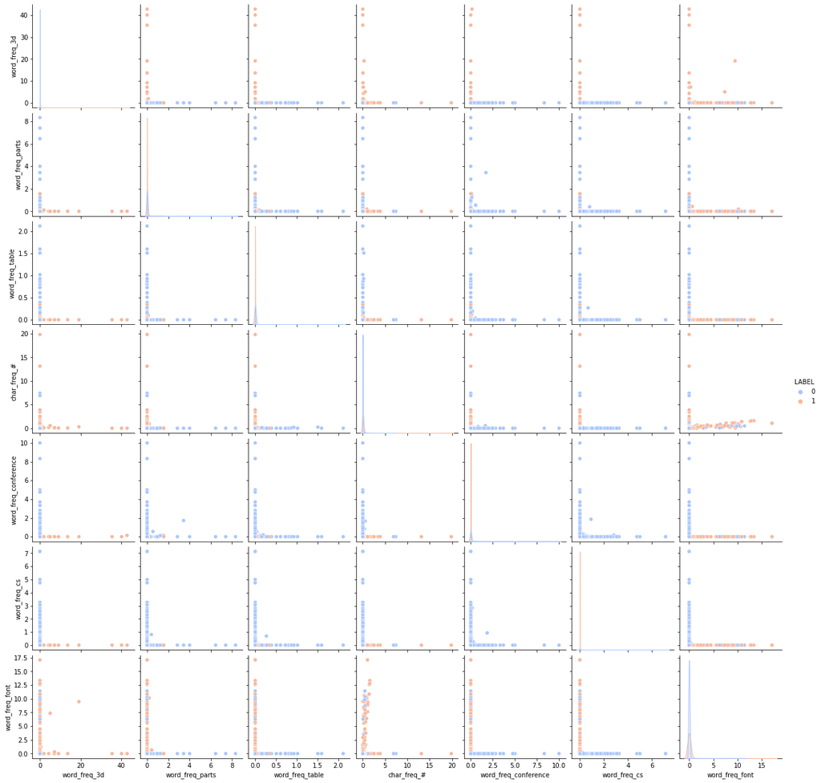

```python
# Scatterplots using target variable as hue
g = sns.pairplot(data=df_train, hue='LABEL', vars=chosen_features, palette='coolwarm')
plt.show()
```

Some of those features have a nearly linearly separable boundary, others don't, indicating the need for testing algorithms with different assumptions about the data.

One this is clear though, I do see a lot more blue dots than red dots, so maybe SMOTE could be of use here.

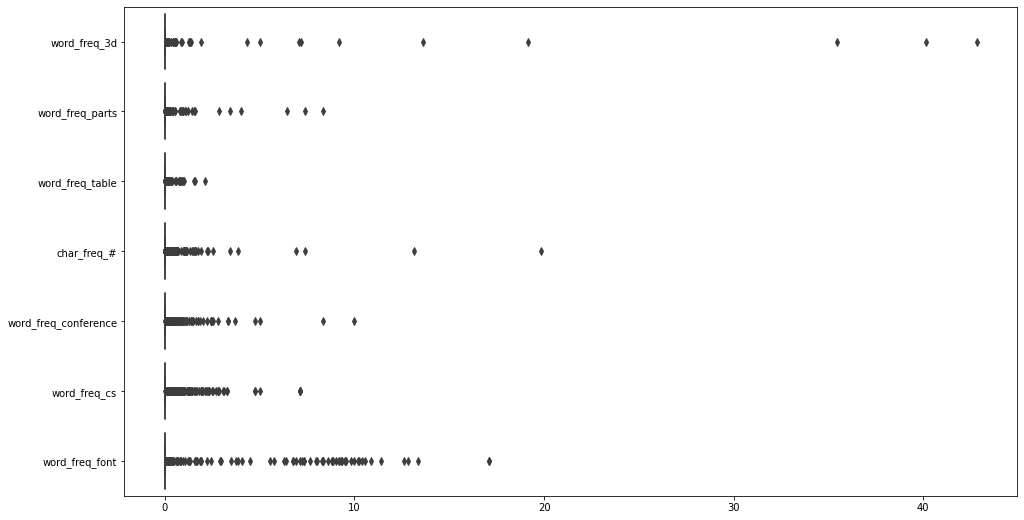

```python
# Boxplots for the highest CV features
fig = plt.figure(figsize=(16,9))
g = sns.boxplot(data=df_train[chosen_features], orient='h')
plt.show()
```

Those boxplots are just more evidence of the need for scaling the variables.

## 2. Building the Classifier

Given the skewness seen in the boxplots, I'll be including a normalizing (StandardScaler) pipeline with all classifiers to be tested.

Additionally, before making a call on which classifier to choose as the final one, I'll first optimize all classifiers using a GridSearch approach.

### 2.1 Defining Grid Searches to Optimize the Classifiers

#### Support Vector Classifier

```python
# Pipeline to standardize then run the classifier
svc =  Pipeline([("standardize", StandardScaler()),
                 ("svc", SVC(kernel="rbf", decision_function_shape='ovr'))])

# Grid with parameters to be tested via CV
svc_param_grid_ = {'svc__C': np.logspace(-3, 3, 5),
                   'svc__gamma': np.logspace(-3, 3, 5)}

# Instantiate GridSearchCV using accuracy as the scorer
svc_gridCV = GridSearchCV(svc, svc_param_grid_, cv=5, n_jobs=-1, scoring='accuracy')
```

#### Random Forest Classifier

```python
# Pipeline to standardize then run the classifier
rfc = Pipeline([("standardize", StandardScaler()),
                 ("rfc", RandomForestClassifier(n_estimators=100, criterion='gini', n_jobs=-1))])

# Grid with parameters to be tested via CV
rfc_param_grid_ = {'rfc__min_samples_split': [2,3],
                   'rfc__min_samples_leaf': [1,2,3]}

# Instantiate GridSearchCV using accuracy as the scorer
rfc_gridCV = GridSearchCV(rfc, rfc_param_grid_, cv=5, n_jobs=-1, scoring='accuracy')
```

#### KNN Classifier

```python
knn = Pipeline([("standardize", StandardScaler()),
                ("knn", KNeighborsClassifier(metric='minkowski', leaf_size=30, weights='distance', n_jobs=-1))])

# Grid with parameters to be tested via CV
knn_param_grid_ = {'knn__n_neighbors': [3,5,7,9]}

# Instantiate GridSearchCV using accuracy as the scorer
knn_gridCV = GridSearchCV(knn, knn_param_grid_, cv=5, n_jobs=-1, scoring='accuracy')
```

#### Gaussian Process Classifier

```python
gpc = Pipeline([("standardize", StandardScaler()),
                ("gpc", GaussianProcessClassifier(optimizer='fmin_l_bfgs_b', max_iter_predict=100, n_jobs=-1))])

# Grid with parameters to be tested via CV
gpc_param_grid_ = {'gpc__n_restarts_optimizer': [0,5,10]}

# Instantiate GridSearchCV using accuracy as the scorer
gpc_gridCV = GridSearchCV(gpc, gpc_param_grid_, cv=5, n_jobs=-1, scoring='accuracy')
```

#### Linear Discriminant Analysis

```python
lda = Pipeline([("standardize", StandardScaler()),
                ("lda", LinearDiscriminantAnalysis(solver='svd'))])

# Grid with parameters to be tested via CV
lda_param_grid_ = {'lda__tol': [1.0e-2, 1.0e-4, 1.0e-6]}

# Instantiate GridSearchCV using accuracy as the scorer
lda_gridCV = GridSearchCV(lda, lda_param_grid_, cv=5, n_jobs=-1, scoring='accuracy')
```

### 2.2. Finding Optimal Hyperparameter with Grid Search & K-Fold Cross-Validation

```python
%%time
# Given the mild imbalance observed in the dataset I'll be adding a SMOTE step to the training data of each K-Fold
smote = SMOTE(n_jobs=-1)

# K-Fold + GridSearch to find the best model hyperparameters
kf = KFold(n_splits=5, shuffle=True)
kfold_intermediate_results = pd.DataFrame()
for fold_num, (idx_train, idx_valid) in enumerate(kf.split(df_train), 1):

    # Print current label and fold
    print(f'Working on Fold: {fold_num}')

    # Select all folds to be smoted except for the validation fold
    x_train, y_train = smote.fit_sample(df_train.iloc[idx_train,:-1], df_train.iloc[idx_train,-1])
    x_valid = df_train.iloc[idx_valid,:-1]
    y_valid = df_train.iloc[idx_valid,-1]

    # Fit using grid search to find the best params
    svc_gridCV.fit(x_train, y_train)
    rfc_gridCV.fit(x_train, y_train)
    knn_gridCV.fit(x_train, y_train)
    gpc_gridCV.fit(x_train, y_train)
    lda_gridCV.fit(x_train, y_train)

    # Predict on the train and validation folds to calculate metrics
    pred_svc_train = svc_gridCV.predict(x_train)
    pred_svc_valid = svc_gridCV.predict(x_valid)
    pred_rfc_train = rfc_gridCV.predict(x_train)
    pred_rfc_valid = rfc_gridCV.predict(x_valid)
    pred_knn_train = knn_gridCV.predict(x_train)
    pred_knn_valid = knn_gridCV.predict(x_valid)
    pred_gpc_train = gpc_gridCV.predict(x_train)
    pred_gpc_valid = gpc_gridCV.predict(x_valid)
    pred_lda_train = lda_gridCV.predict(x_train)
    pred_lda_valid = lda_gridCV.predict(x_valid)

    # Store best params of each classifier for each fold
    kfold_intermediate_results.at['SVC_C', f'{fold_num}'] = svc_gridCV.best_params_['svc__C']
    kfold_intermediate_results.at['SVC_gamma', f'{fold_num}'] = svc_gridCV.best_params_['svc__gamma']
    kfold_intermediate_results.at['RFC_split', f'{fold_num}'] = rfc_gridCV.best_params_['rfc__min_samples_split']
    kfold_intermediate_results.at['RFC_leaf', f'{fold_num}'] = rfc_gridCV.best_params_['rfc__min_samples_leaf']
    kfold_intermediate_results.at['KNN_N', f'{fold_num}'] = knn_gridCV.best_params_['knn__n_neighbors']
    kfold_intermediate_results.at['GPC_restarts', f'{fold_num}'] = gpc_gridCV.best_params_['gpc__n_restarts_optimizer']
    kfold_intermediate_results.at['LDA_tol', f'{fold_num}'] = lda_gridCV.best_params_['lda__tol']

    # Store errors for each model in each fold
    kfold_intermediate_results.at['SVC_train', f'{fold_num}'] = 1-accuracy_score(y_true=y_train, y_pred=pred_svc_train)
    kfold_intermediate_results.at['SVC_valid', f'{fold_num}'] = 1-accuracy_score(y_true=y_valid, y_pred=pred_svc_valid)
    kfold_intermediate_results.at['RFC_train', f'{fold_num}'] = 1-accuracy_score(y_true=y_train, y_pred=pred_rfc_train)
    kfold_intermediate_results.at['RFC_valid', f'{fold_num}'] = 1-accuracy_score(y_true=y_valid, y_pred=pred_rfc_valid)
    kfold_intermediate_results.at['KNN_train', f'{fold_num}'] = 1-accuracy_score(y_true=y_train, y_pred=pred_knn_train)
    kfold_intermediate_results.at['KNN_valid', f'{fold_num}'] = 1-accuracy_score(y_true=y_valid, y_pred=pred_knn_valid)
    kfold_intermediate_results.at['GPC_train', f'{fold_num}'] = 1-accuracy_score(y_true=y_train, y_pred=pred_gpc_train)
    kfold_intermediate_results.at['GPC_valid', f'{fold_num}'] = 1-accuracy_score(y_true=y_valid, y_pred=pred_gpc_valid)
    kfold_intermediate_results.at['LDA_train', f'{fold_num}'] = 1-accuracy_score(y_true=y_train, y_pred=pred_lda_train)
    kfold_intermediate_results.at['LDA_valid', f'{fold_num}'] = 1-accuracy_score(y_true=y_valid, y_pred=pred_lda_valid)

# After running all K-Folds get average results for each classifier
kfold_intermediate_results['mean'] = kfold_intermediate_results.mean(axis=1)

print()
print('--- GridSearch Best Parameters ---')
print(f'Mean SVC C Parameter: {kfold_intermediate_results["mean"]["SVC_C"]}')
print(f'Mean SVC gamma Parameter: {kfold_intermediate_results["mean"]["SVC_gamma"]}')
print(f'Mean RFC min_samples_split Parameter: {kfold_intermediate_results["mean"]["RFC_split"]}')
print(f'Mean RFC min_samples_leaf Parameter: {kfold_intermediate_results["mean"]["RFC_leaf"]}')
print(f'Mean KNN N Parameter: {kfold_intermediate_results["mean"]["KNN_N"]}')
print(f'Mean GPA n_restarts_optimizer Parameter: {kfold_intermediate_results["mean"]["GPC_restarts"]}')
print(f'Mean LDA tol Parameter: {kfold_intermediate_results["mean"]["LDA_tol"]}')
print()
print('--- K-Fold Cross-Validation Results ---')
print(f'SVC Error | Training : {kfold_intermediate_results["mean"]["SVC_train"]}')
print(f'RFC Error | Training : {kfold_intermediate_results["mean"]["RFC_train"]}')
print(f'KNN Error | Training : {kfold_intermediate_results["mean"]["KNN_train"]}')
print(f'GPC Error | Training : {kfold_intermediate_results["mean"]["GPC_train"]}')
print(f'LDA Error | Training : {kfold_intermediate_results["mean"]["LDA_train"]}')
print()
print(f'SVC Error | Validation : {kfold_intermediate_results["mean"]["SVC_valid"]}')
print(f'RFC Error | Validation : {kfold_intermediate_results["mean"]["RFC_valid"]}')
print(f'KNN Error | Validation : {kfold_intermediate_results["mean"]["KNN_valid"]}')
print(f'GPC Error | Validation : {kfold_intermediate_results["mean"]["GPC_valid"]}')
print(f'LDA Error | Validation : {kfold_intermediate_results["mean"]["LDA_valid"]}')
print()
```

```
Working on Fold: 1
Working on Fold: 2
Working on Fold: 3
Working on Fold: 4
Working on Fold: 5

--- GridSearch Best Parameters ---
Mean SVC C Parameter: 1000.0
Mean SVC gamma Parameter: 0.001
Mean RFC min_samples_split Parameter: 2.2
Mean RFC min_samples_leaf Parameter: 1.0
Mean KNN N Parameter: 7.8
Mean GPA n_restarts_optimizer Parameter: 0.0
Mean LDA tol Parameter: 0.01

--- K-Fold Cross-Validation Results ---
SVC Error | Training : 0.03290193784820476
RFC Error | Training : 0.0006722528969830943
KNN Error | Training : 0.0005607080001621245
GPC Error | Training : 0.009920530100554359
LDA Error | Training : 0.09024132695878322

SVC Error | Validation : 0.06467391304347825
RFC Error | Validation : 0.04646739130434783
KNN Error | Validation : 0.08478260869565216
GPC Error | Validation : 0.07717391304347827
LDA Error | Validation : 0.09347826086956519

Wall time: 12min 48s
```

Considering the validation data the Random Forest Classifier is ahead, but none of the other algorithms is too far behind! Let me now use the best hyperparameters from each K-Fold iteration to build a final version of each model to be tested on the test dataset, so that I can select the best model.

### 2.3. Comparing Results of the Optimized Classifiers & Selecting the Best

```python
# Dataframe to store results
summary = pd.DataFrame()

# Create new classifiers using the average of the best parameters in each k-fold
svc_kfold = Pipeline([("standardize", StandardScaler()),
                      ("svc", SVC(kernel="rbf", decision_function_shape='ovr',
                                  C=kfold_intermediate_results.at['SVC_C', 'mean'],
                                  gamma=kfold_intermediate_results.at['SVC_gamma', 'mean']))])

rfc_kfold = Pipeline([("standardize", StandardScaler()),
                      ("rfc", RandomForestClassifier(n_estimators=100, criterion='gini', n_jobs=-1,
                                                     min_samples_split=round(kfold_intermediate_results.at['RFC_split', 'mean']),
                                                     min_samples_leaf=round(kfold_intermediate_results.at['RFC_leaf', 'mean'])))])

knn_kfold = Pipeline([("standardize", StandardScaler()),
                      ("knn", KNeighborsClassifier(metric='minkowski', leaf_size=30, weights='distance', n_jobs=-1,
                                                   n_neighbors=round(kfold_intermediate_results.at['KNN_N', 'mean'])))])

gpc_kfold = Pipeline([("standardize", StandardScaler()),
                      ("gpc", GaussianProcessClassifier(optimizer='fmin_l_bfgs_b', max_iter_predict=100, n_jobs=-1,
                                                        n_restarts_optimizer=round(kfold_intermediate_results["mean"]["GPC_restarts"])))])

lda_kfold = Pipeline([("standardize", StandardScaler()),
                      ("lda", LinearDiscriminantAnalysis(solver='svd',
                                                         tol=kfold_intermediate_results.at['LDA_tol', 'mean']))])


# Get X's and Y's - This time using the full datasets for trainin and testing
x_train, y_train = smote.fit_sample(df_train.iloc[:,:-1], df_train.iloc[:,-1])
x_test = df_test.iloc[:, :-1].copy()
y_test = df_test.iloc[:, -1].copy()

# Fit using the optimized model created with the mean hyperparameters from K-Fold cross-validation
svc_kfold.fit(x_train, y_train)
rfc_kfold.fit(x_train, y_train)
knn_kfold.fit(x_train, y_train)
gpc_kfold.fit(x_train, y_train)
lda_kfold.fit(x_train, y_train)

# Predict
pred_svc_train = svc_kfold.predict(x_train)
pred_svc_test = svc_kfold.predict(x_test)
pred_rfc_train = rfc_kfold.predict(x_train)
pred_rfc_test = rfc_kfold.predict(x_test)
pred_knn_train = knn_kfold.predict(x_train)
pred_knn_test = knn_kfold.predict(x_test)
pred_gpc_train = gpc_kfold.predict(x_train)
pred_gpc_test = gpc_kfold.predict(x_test)
pred_lda_train = gpc_kfold.predict(x_train)
pred_lda_test = gpc_kfold.predict(x_test)

# Model Error
summary.at['train', f'SVC'] = 1-accuracy_score(y_true=y_train, y_pred=pred_svc_train)
summary.at['test', f'SVC'] = 1-accuracy_score(y_true=y_test, y_pred=pred_svc_test)
summary.at['train', f'RFC'] = 1-accuracy_score(y_true=y_train, y_pred=pred_rfc_train)
summary.at['test', f'RFC'] = 1-accuracy_score(y_true=y_test, y_pred=pred_rfc_test)
summary.at['train', f'KNN'] = 1-accuracy_score(y_true=y_train, y_pred=pred_knn_train)
summary.at['test', f'KNN'] = 1-accuracy_score(y_true=y_test, y_pred=pred_knn_test)
summary.at['train', f'GPC'] = 1-accuracy_score(y_true=y_train, y_pred=pred_gpc_train)
summary.at['test', f'GPC'] = 1-accuracy_score(y_true=y_test, y_pred=pred_gpc_test)
summary.at['train', f'LDA'] = 1-accuracy_score(y_true=y_train, y_pred=pred_lda_train)
summary.at['test', f'LDA'] = 1-accuracy_score(y_true=y_test, y_pred=pred_lda_test)

# Print model results for optimized classifiers model
print(f'------------------------------ MODEL OVERALL ------------------------------')
print('SVC Error | Training: ', summary.at['train', f'SVC'])
print('RFC Error | Training: ', summary.at['train', f'RFC'])
print('KNN Error | Training: ', summary.at['train', f'KNN'])
print('GPC Error | Training: ', summary.at['train', f'GPC'])
print('LDA Error | Training: ', summary.at['train', f'LDA'])
print()
print('SVC Error | Testing: ', summary.at['test', f'SVC'])
print('RFC Error | Testing: ', summary.at['test', f'RFC'])
print('KNN Error | Testing: ', summary.at['test', f'KNN'])
print('GPC Error | Testing: ', summary.at['test', f'GPC'])
print('LDA Error | Testing: ', summary.at['test', f'LDA'])
```

```
------------------------------ MODEL OVERALL ------------------------------
SVC Error | Training:  0.03385650224215242
RFC Error | Training:  0.0006726457399103269
KNN Error | Training:  0.0006726457399103269
GPC Error | Training:  0.010313901345291532
LDA Error | Training:  0.010313901345291532

SVC Error | Testing:  0.06514657980456029
RFC Error | Testing:  0.057546145494028256
KNN Error | Testing:  0.07709011943539634
GPC Error | Testing:  0.07600434310532034
LDA Error | Testing:  0.07600434310532034
```

```python
# View results in the dataframe
summary
```

|  | SVC | RFC | KNN | GPC | LDA |
| --- | --- | --- | --- | --- | --- |
| train | 0.033857 | 0.000673 | 0.000673 | 0.010314 | 0.010314 |
| test | 0.065147 | 0.057546 | 0.077090 | 0.076004 | 0.076004 |

Among the optimized models there were many ties in the training set, but when looking at the testing set, the Random Forecast Classifier is the clear winner!

But before I move ahead to calculating the performance metrics for our winning algorithm, let's introduce one final challenger: TPOT's AutoML.

### Bonus: AutoML

Attempting to improve on the performance of the best classifier by using TPOT's AutoML tool to search for an ideal classifier pipeline.

TPOT AutoML Documentation: http://epistasislab.github.io/tpot/

```python
# Split X and Y
x_train = df_train.iloc[:,:-1]
y_train= df_train.iloc[:,-1]
x_test = df_test.iloc[:,:-1]
y_test= df_test.iloc[:,-1]
```

```python
#Instantiate and run the AutoML classifier
AutoML = TPOTClassifier(generations=5, population_size=20, cv=5, verbosity=2, n_jobs=-1)
AutoML.fit(x_train, y_train)
```

```
Generation 1 - Current best internal CV score: 0.9461956521739131

Generation 2 - Current best internal CV score: 0.9461956521739131

Generation 3 - Current best internal CV score: 0.9470108695652174

Generation 4 - Current best internal CV score: 0.9470108695652174

Generation 5 - Current best internal CV score: 0.9475543478260869

Best pipeline: XGBClassifier(BernoulliNB(input_matrix, alpha=1.0, fit_prior=False), learning_rate=0.1, max_depth=9, min_child_weight=12, n_estimators=100, n_jobs=1, subsample=0.6000000000000001, verbosity=0)
```

```
TPOTClassifier(generations=5, n_jobs=-1, population_size=20, verbosity=2)
```

```python
# And the best model is:
AutoML.fitted_pipeline_.steps[-1][1]
```

```
XGBClassifier(base_score=0.5, booster='gbtree', colsample_bylevel=1,
              colsample_bynode=1, colsample_bytree=1, gamma=0, gpu_id=-1,
              importance_type='gain', interaction_constraints='',
              learning_rate=0.1, max_delta_step=0, max_depth=9,
              min_child_weight=12, missing=nan, monotone_constraints='()',
              n_estimators=100, n_jobs=1, num_parallel_tree=1, random_state=0,
              reg_alpha=0, reg_lambda=1, scale_pos_weight=1,
              subsample=0.6000000000000001, tree_method='exact',
              validate_parameters=1, verbosity=0)
```

```python
# Check performance
print("AutoML Error | Training: ", 1-AutoML.score(x_train, y_train))
print("AutoML Error | Testing: ", 1-AutoML.score(x_test, y_test))
```

```
AutoML Error | Training:  0.03505434782608696
AutoML Error | Testing:  0.061889250814332275
```

Looks like TPOT proved no match for our Random Forest Classifier, so let's move ahead with extracting performance metrics for our champion.

## 3. Evaluating the Results

### 3.1. K-Fold Cross-Validation for the Best Model

Now the the best model has been identified, rerun a K-Fold cross-validation without using SMOTE, so that more representative FPR, FNR and Error values can be obtained

```python
# Now let's run a K-Fold cross-validation with the winner model and see how it performs over each fold
kf = KFold(n_splits=5, shuffle=True)
scores_train, scores_valid, scores_test = pd.DataFrame(), pd.DataFrame(), pd.DataFrame()
for fold_num, (idx_train, idx_valid) in enumerate(kf.split(df_train), 1):

    # Print current label and fold
    print(f'Working on Fold: {fold_num}')

    # Select all folds to be smoted except for the validation fold
    x_train = df_train.iloc[idx_train,:-1].copy()
    y_train = df_train.iloc[idx_train,-1].copy()
    x_valid = df_train.iloc[idx_valid,:-1].copy()
    y_valid = df_train.iloc[idx_valid,-1].copy()
    x_test = df_test.iloc[:, :-1].copy()
    y_test = df_test.iloc[:, -1].copy()

    # Fit a Random Forest Classifier using the best parameters
    winner_model = Pipeline([("standardize", StandardScaler()),
                              ("rfc", RandomForestClassifier(n_estimators=100, criterion='gini', n_jobs=-1,
                                      min_samples_split=round(kfold_intermediate_results.at['RFC_split', 'mean']),
                                      min_samples_leaf=round(kfold_intermediate_results.at['RFC_leaf', 'mean'])))])

    winner_model.fit(x_train, y_train)

    # Predict on the train and validation folds to calculate metrics (with the winnier rfc_kfold model)
    pred_train = winner_model.predict(x_train)
    pred_valid = winner_model.predict(x_valid)
    pred_test = winner_model.predict(x_test)

    # Train dataset metrics
    scores_train.at[f'{fold_num}', 'Error'] = 1-accuracy_score(y_true=y_train, y_pred=pred_train)
    cm_train = confusion_matrix(y_train, pred_train)
    TN, FP, FN, TP = cm_train.ravel()
    scores_train.at[f'{fold_num}', 'FPR'] = FP/(FP+TN)
    scores_train.at[f'{fold_num}', 'FNR'] = FN/(TP+FN)

    # Valid dataset metrics
    scores_valid.at[f'{fold_num}', 'Error'] = 1-accuracy_score(y_true=y_valid, y_pred=pred_valid)
    cm_valid = confusion_matrix(y_valid, pred_valid)
    TN, FP, FN, TP = cm_valid.ravel()
    scores_valid.at[f'{fold_num}', 'FPR'] = FP/(FP+TN)
    scores_valid.at[f'{fold_num}', 'FNR'] = FN/(TP+FN)

    # Test dataset metrics
    scores_test.at[f'{fold_num}', 'Error'] = 1-accuracy_score(y_true=y_test, y_pred=pred_test)
    cm_test = confusion_matrix(y_test, pred_test)
    TN, FP, FN, TP = cm_test.ravel()
    scores_test.at[f'{fold_num}', 'FPR'] = FP/(FP+TN)
    scores_test.at[f'{fold_num}', 'FNR'] = FN/(TP+FN)

# Get mean scores over all K-folds
scores_train.at['mean', 'Error'] = scores_train['Error'].mean()
scores_train.at['mean', 'FPR'] = scores_train['FPR'].mean()
scores_train.at['mean', 'FNR'] = scores_train['FNR'].mean()
scores_valid.at['mean', 'Error'] = scores_valid['Error'].mean()
scores_valid.at['mean', 'FPR'] = scores_valid['FPR'].mean()
scores_valid.at['mean', 'FNR'] = scores_valid['FNR'].mean()
scores_test.at['mean', 'Error'] = scores_test['Error'].mean()
scores_test.at['mean', 'FPR'] = scores_test['FPR'].mean()
scores_test.at['mean', 'FNR'] = scores_test['FNR'].mean()
```

```
Working on Fold: 1
Working on Fold: 2
Working on Fold: 3
Working on Fold: 4
Working on Fold: 5
```

```python
scores_train
```

|  | Error | FPR | FNR |
| --- | --- | --- | --- |
| 1 | 0.000679 | 0.000562 | 0.000859 |
| 2 | 0.001019 | 0.001115 | 0.000870 |
| 3 | 0.000679 | 0.000558 | 0.000867 |
| 4 | 0.000340 | 0.000564 | 0.000000 |
| 5 | 0.000340 | 0.000561 | 0.000000 |
| mean | 0.000611 | 0.000672 | 0.000519 |

```python
scores_valid
```

|  | Error | FPR | FNR |
| --- | --- | --- | --- |
| 1 | 0.052989 | 0.031111 | 0.087413 |
| 2 | 0.043478 | 0.011468 | 0.090000 |
| 3 | 0.061141 | 0.052392 | 0.074074 |
| 4 | 0.042120 | 0.030702 | 0.060714 |
| 5 | 0.040761 | 0.031180 | 0.055749 |
| mean | 0.048098 | 0.031371 | 0.073590 |

```python
scores_test
```

|  | Error | FPR | FNR |
| --- | --- | --- | --- |
| 1 | 0.055375 | 0.034050 | 0.088154 |
| 2 | 0.057546 | 0.028674 | 0.101928 |
| 3 | 0.058632 | 0.034050 | 0.096419 |
| 4 | 0.054289 | 0.030466 | 0.090909 |
| 5 | 0.056460 | 0.030466 | 0.096419 |
| mean | 0.056460 | 0.031541 | 0.094766 |

Note: It is possible to obtain all the metrics (error, FPR, FNR) while comparing all optimized models.

I've chosen to first (2.3) compare all models and then later (3.1) re-train the winning model and calculate the metrics only for that model for the sake of clarity, as I believe this apporach makes the step-by-step of the pipeline I've implemented clearer.

### 3.2. Confusion Matrix and ROC-AUC Curve for the Best Model

```python
# Function to plot confusion matrix
def show_confusion_matrix(confusion_matrix):
    hmap = sns.heatmap(confusion_matrix, annot = True, fmt = "d", cmap = "Blues", square=True)
    hmap.yaxis.set_ticklabels(hmap.yaxis.get_ticklabels(), rotation = 0, ha = "right")
    hmap.xaxis.set_ticklabels(hmap.xaxis.get_ticklabels(), rotation = 0, ha = "right")
    plt.title('Confusion Matrix', pad=20, fontweight='bold', fontsize=15)
    plt.ylabel('True Class')
    plt.xlabel('Predicted Class')
```

```python
# Function to plot ROC-AUC Curve
def show_roc_curve(roc_curve):
    auc_score = auc(roc_curve[0], roc_curve[1])
    plt.axis('square')
    plt.plot(roc_curve[0], roc_curve[1], color='tomato', lw=3, label='AUC: ' + str(auc_score))
    plt.plot([0, 1], [0, 1], 'k--', lw=1.5)
    plt.xlim([-0.01, 1.01])
    plt.ylim([-0.01, 1.01])
    plt.xlabel('False Positive Rate')
    plt.ylabel('True Positive Rate')
    plt.title('ROC Curve', pad=20, fontweight='bold', fontsize=15)
    legend = plt.legend('AUC Score')
    legend._legend_box.align = "right"
    plt.legend(loc="lower right")
```

```python
# Use the trained model to predict on both train and test datasets (now without smoting them)
pred_train = rfc_kfold.predict(x_train)
pred_test = rfc_kfold.predict(x_test)

# Confusion Matrix
cm_train = confusion_matrix(y_true=y_train, y_pred=pred_train)
cm_test = confusion_matrix(y_true=y_test, y_pred=pred_test)

# ROC Curve
roc_train = roc_curve(y_true=y_train, y_score=pred_train)
roc_test = roc_curve(y_true=y_test, y_score=pred_test)
```

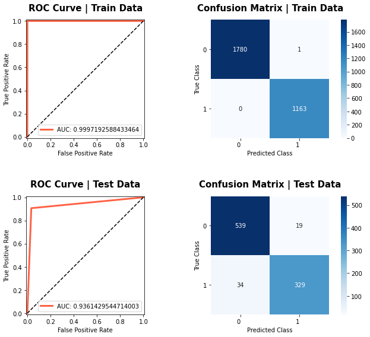

```python
# Create Figure
fig, ax = plt.subplots(nrows=2, ncols=2, figsize=(10,8))

# Plot Train ROC Curve
plt.subplot(2,2,1)
show_roc_curve(roc_train)
plt.title('ROC Curve | Train Data', fontsize=15, fontweight='bold', pad=15)

# Plot Train Confusion Matrix
plt.subplot(2,2,2)
show_confusion_matrix(cm_train)
plt.title('Confusion Matrix | Train Data', fontsize=15, fontweight='bold', pad=15)

# Plot Test ROC Curve
plt.subplot(2,2,3)
show_roc_curve(roc_test)
plt.title('ROC Curve | Test Data', fontsize=15, fontweight='bold', pad=15)

# Plot Test Confusion Matrix
plt.subplot(2,2,4)
show_confusion_matrix(cm_test)
plt.title('Confusion Matrix | Test Data', fontsize=15, fontweight='bold', pad=15)

fig.tight_layout(h_pad=4, w_pad=-10)
```

## End

Matheus Schmitz  
[LinkedIn](https://www.linkedin.com/in/matheusschmitz/)  
[Github Portfolio](https://matheus-schmitz.github.io/)